# Significance

## 2016 Polls and “Shy Trump Supporters”

Pollsters underestimated Trump’s support in many key states the 2016 election, could *social desirability bias* explain the discrepancy?

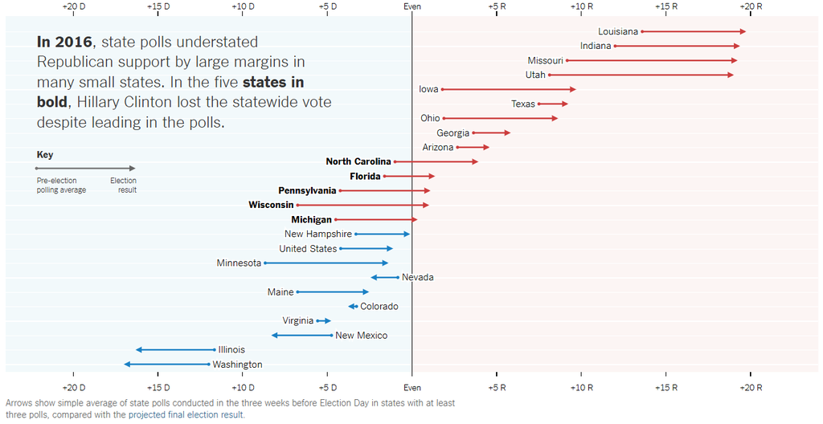

## The “Shy Trump Voter”

> …[2020] *polls could again be undercounting Trump’s support. The reason is “shy” Trump voters—people reluctant to share their opinions for fear of being judged*

[figure not shown]

## Looking for Shy Trump Supporters

Are Trump supporters more likely to misreport their views? How would we show evidence for/against this claim?

## Looking for Shy Trump Supporters

Pew Research Courtney Kennedy and Lau (2017) used a survey experiment to look at the effects of phone vs. online polls on supporting Trump/Trump admin policies.

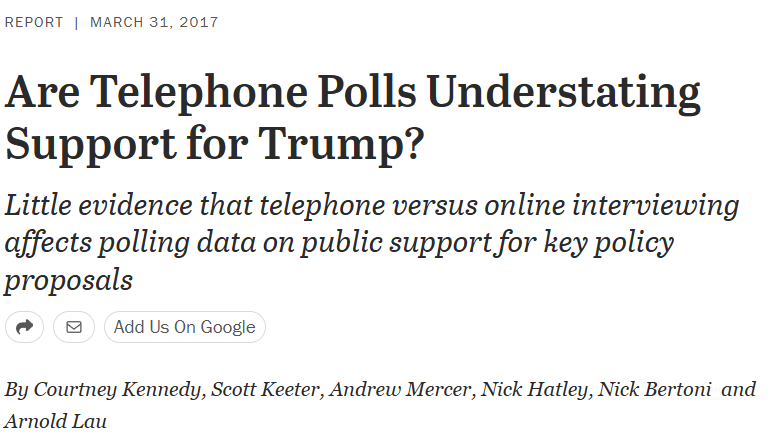

### Looking for Shy Trump Supporters

Pew’s Methodology:

- Randomly assign respondents to answer the same 27 questions by phone (n=1,778) or online (n=2,066)
- Compare average support across different survey modes to look for evidence of social desirability bias.

### Looking for Shy Trump Supporters

- There’s a small difference in Trump support across survey modes. But the authors say is is *not statistically significant*.
- There are some statistically significant differences, but they don’t all go in the direction one would expect.

[figure not shown]

### Looking for Shy Trump Supporters

So what does this mean, and how do we know it?

### Central Limit Theorem and sampling distributions

Under the Central Limit Theorem, we know that the sampling distribution of a sample mean:

1. Will be approximately normal distributed.
2. Will be centered around the population mean.
3. Will have a standard deviation (standard error) of $\sqrt{\frac{s^2}{n}}$

[figure not shown]

### Central Limit Theorem and sampling distributions

We can use this knowledge to quantify how much uncertainty we have around a single sample mean.

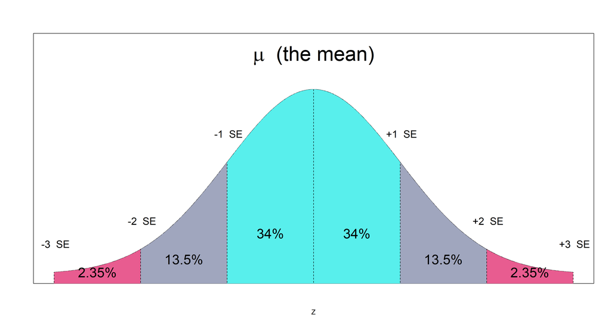

### Linear combinations of random normal variables

Moreover: **linear combinations (addition/subtraction) of random normal variables are themselves normally distributed.**

### Linear combinations of random normal variables

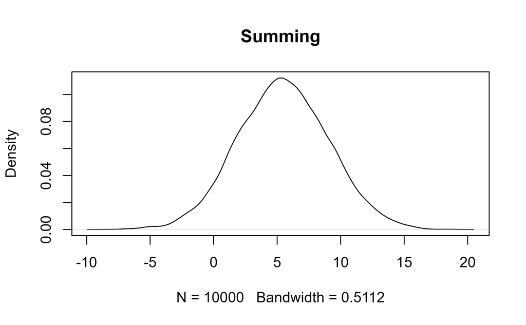

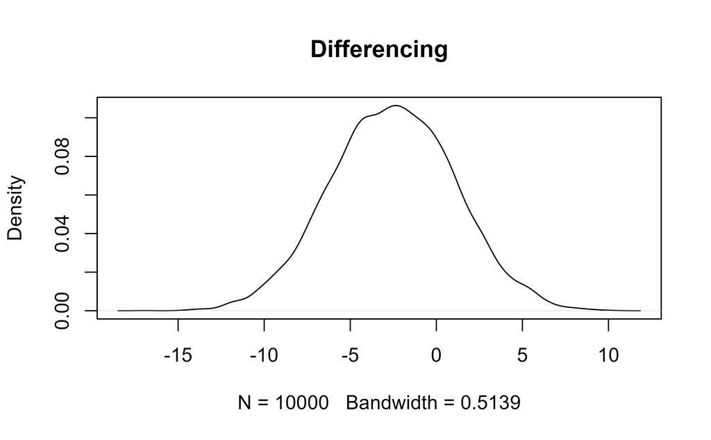

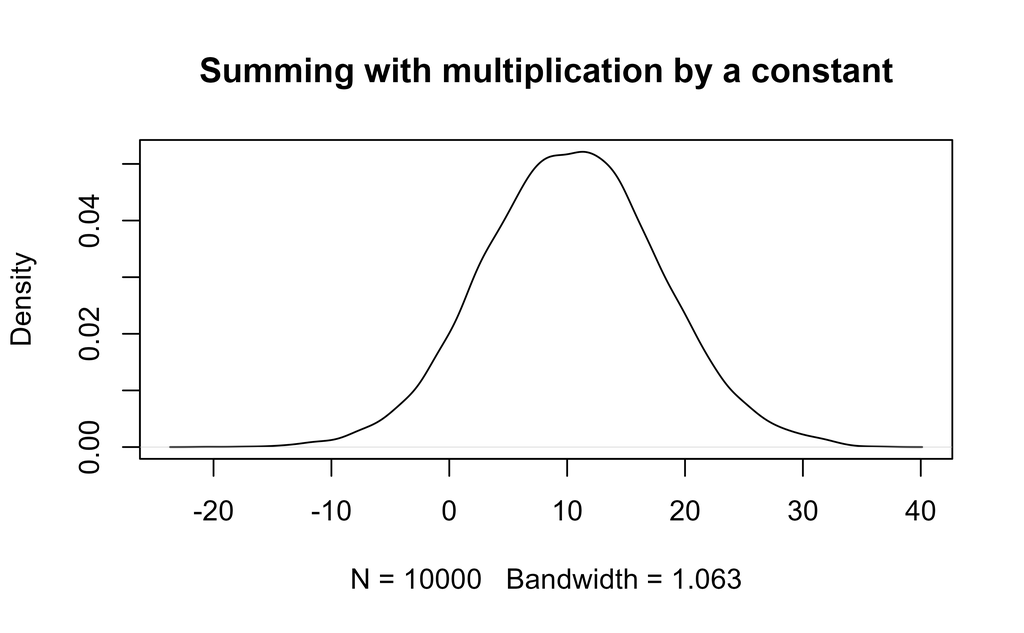

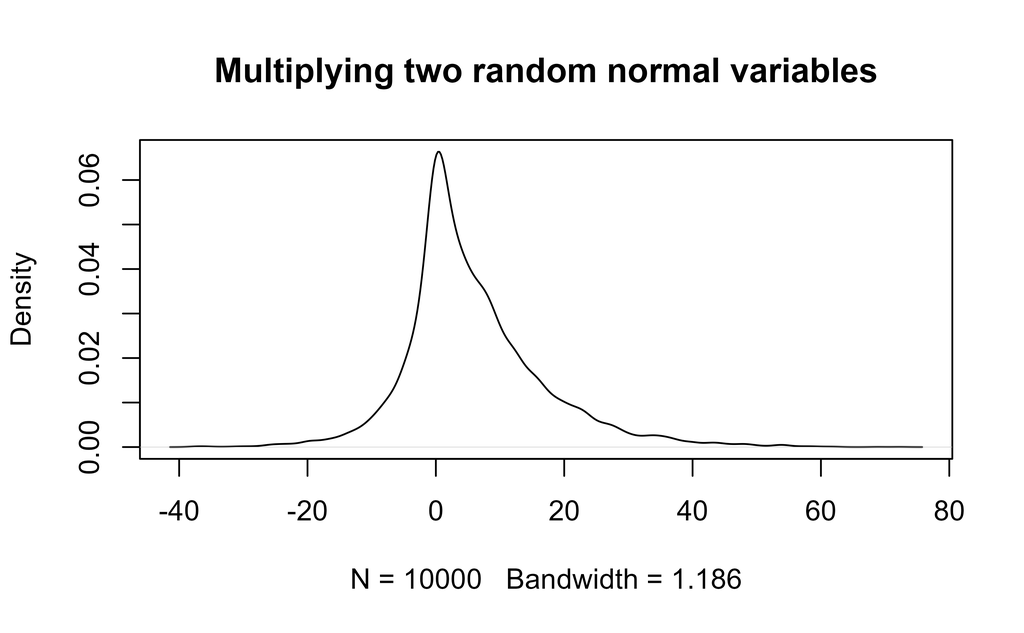

```r
n<-10000
x1<-rnorm(n, mean=1.5, sd=2)
x2<-rnorm(n, mean=4, sd=3)
plot(density(x1 + x2),
     main ='Summing')
plot(density(x1 - x2),
     main='Differencing')
plot(density(x1*3 + x2*1.5),
     main = "Summing with multiplication by a constant")
plot(density(x1 * x2),
     main ='Multiplying two random normal variables')
```

### Sampling distributions of a difference

We can also make inferences about the difference between two sampling distributions using the same basic logic we used to build a confidence interval around a single estimate.

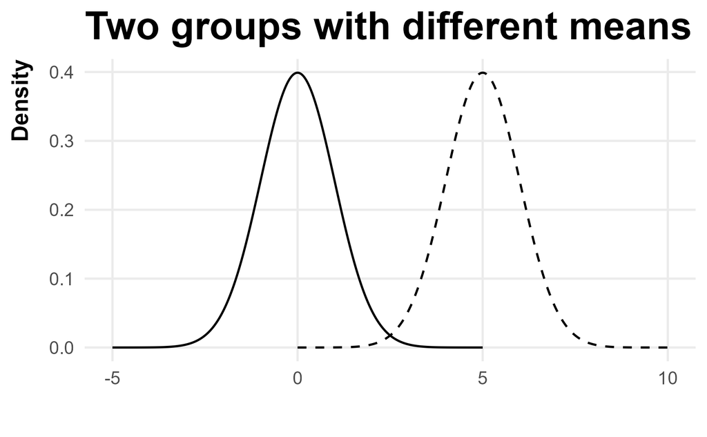

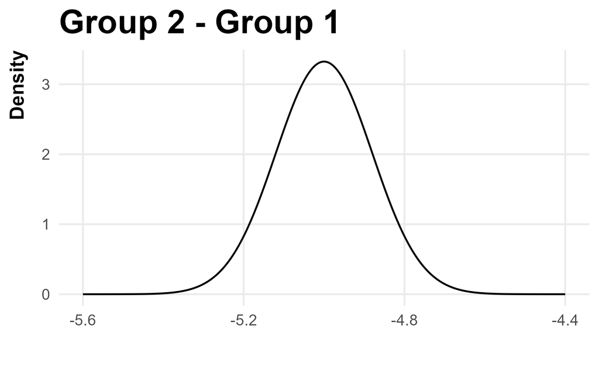

### Confidence intervals for a difference

To get a confidence interval, we just need to find the variance for this sampling distribution.

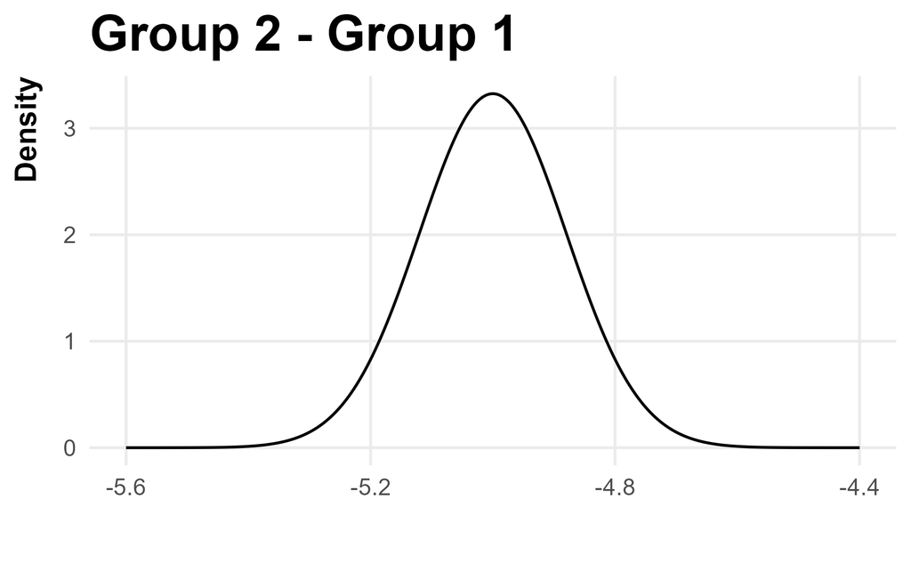

### Confidence intervals for a difference

The standard error of the difference between two means is just a weighted combination of their respective variances:

$$\text{SE}_{\bar{y}_{a} - \bar{y}_{b}} = \sqrt{\frac{s^2_a}{n_a} + \frac{s^2_b}{n_b}}$$

For example: if $s_a^2 = 10$, $n_a=100$ and $s_b^2 = 20$, $b_2 = 100$, then:

$$\text{SE}(\bar{y}_1 - \bar{y}_2) = \sqrt{\frac{10}{100} + \frac{20}{100}} = 0.55$$

### Confidence intervals for a difference

In Pew’s study:

- Phone respondents had 42% approval for Trump at a sample size of 1,778.
- Web respondents had 44% approval for Trump at a sample size of 2,066.
- Pew reports the sample variances as: $s^2_{\text{phone}} = 0.244$ and $s^2_{\text{web}} = 0.246$

### Confidence intervals for a difference

$$\bar{y}_{\text{web}} - \bar{y}_{\text{phone}} = 0.02$$

$$s^2_{\text{phone}} = 0.244; n_{\text{phone}} =1,778$$

$$s^2_{\text{web}} = 0.246; n_{\text{web}} =2,066$$

$$SE_{\bar{y}_{\text{web}} - \bar{y}_{\text{phone}}} = \sqrt{\frac{0.244}{1,778} + \frac{0.246}{2,066}} = 0.016$$

### Confidence intervals for a difference

From here, we can calculate the 95% margin of error using the same strategy we used for a confidence interval $\text{SE}_\text{diff} \times 1.96 = 0.031$

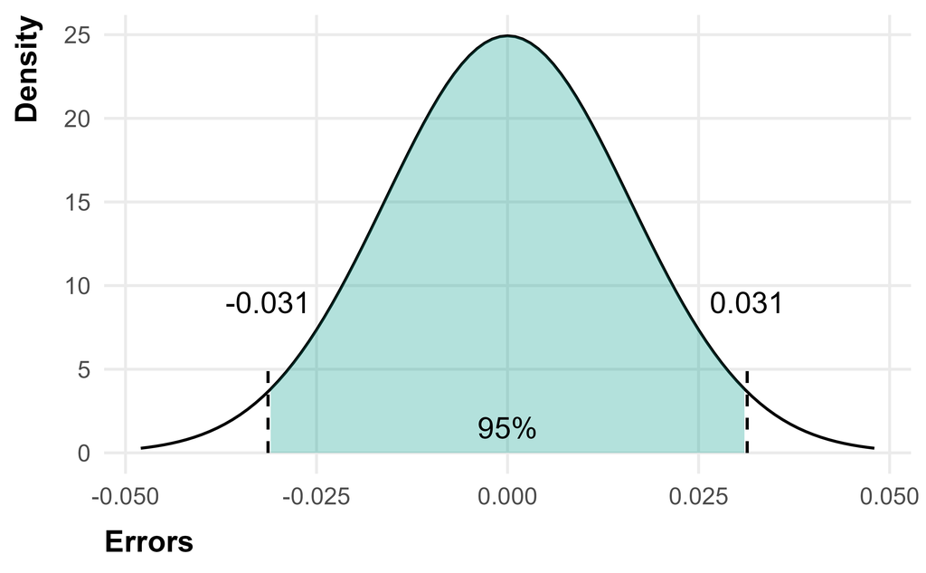

### Confidence intervals for a difference

We are 95% confident that the effect of web vs. phone surveys is between -1% and +5%

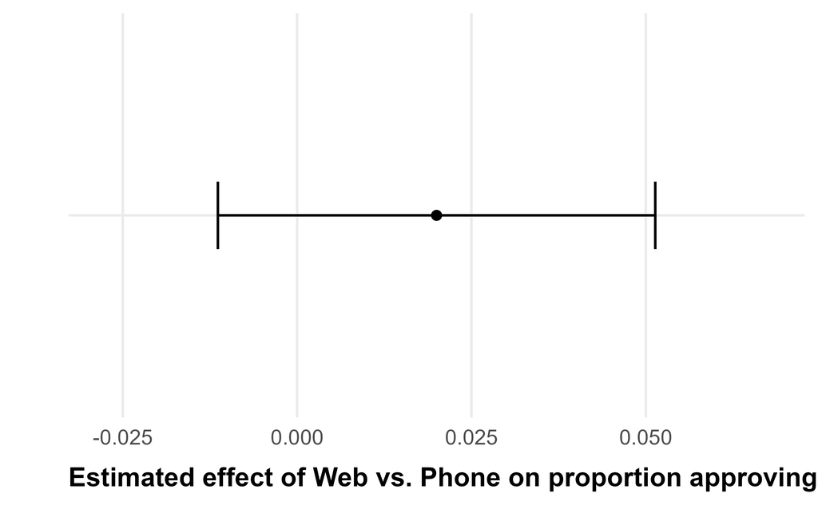

### Confidence intervals for a difference

Note that this range includes a negative effect, *and* a positive effect *and* no effect at all.

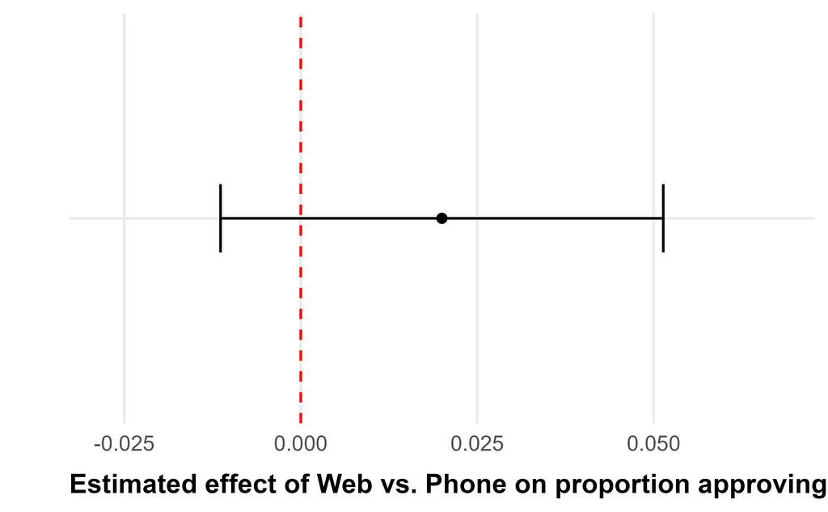

### Confidence intervals for a difference

In broad terms, “non-significance” means we can’t rule out a positive, negative, or null effect.

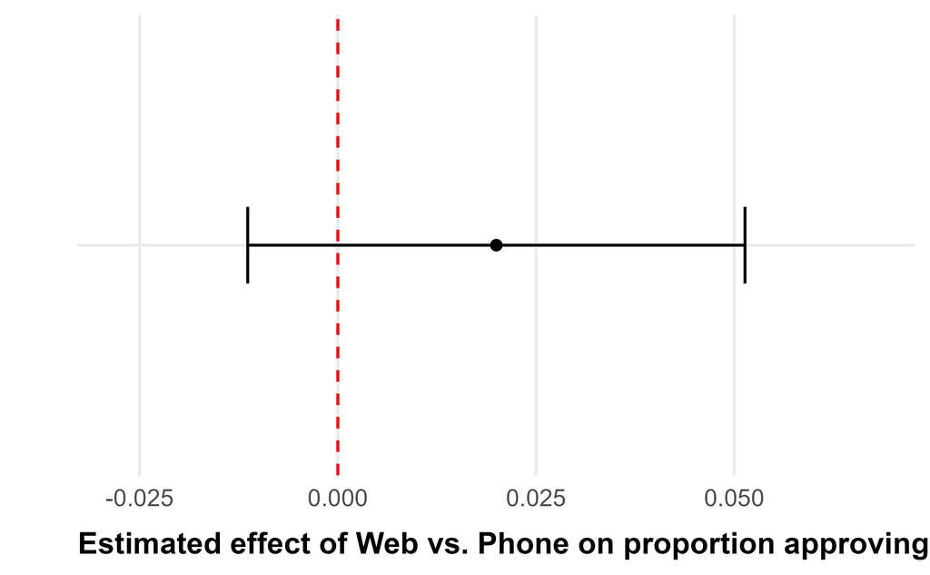

### Confidence intervals for a difference

Note here, that there are *some* confidence levels where we could rule this out.

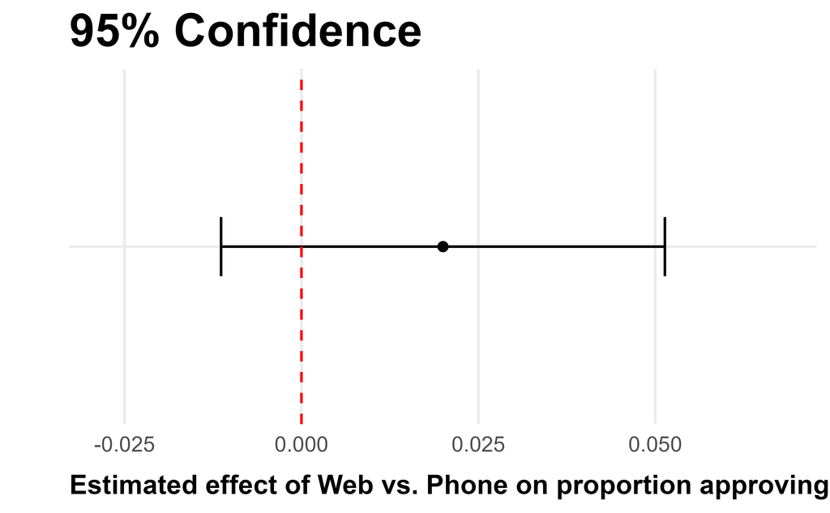

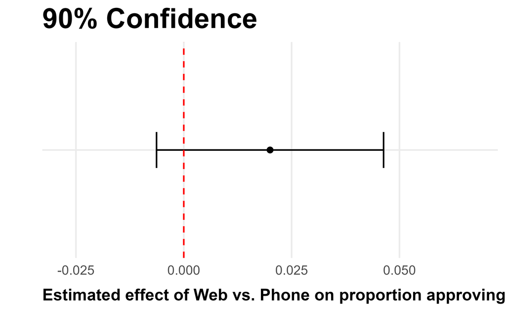

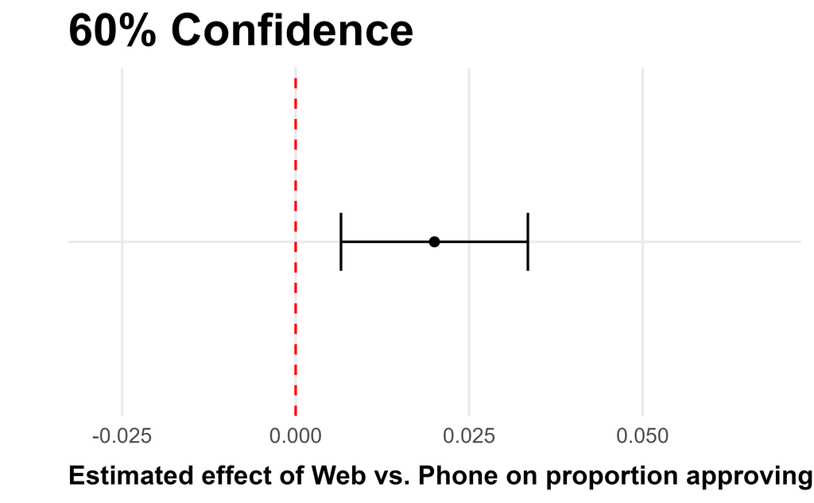

### Confidence intervals for a difference

95% Confidence ranges are typically used *by convention*, which is why you’ll often see the phrase *conventional levels of statistical significance*.

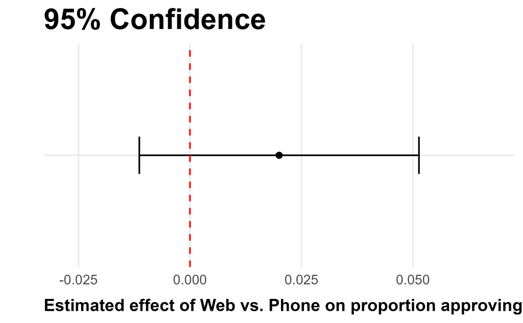

### P values for a difference

**P values** are just an alternative method for conveying this same basic idea. A p-value represents the probability of seeing a result at least as large as the one in our sample if a null hypothesis is true.

In this case, our null hypothesis would typically be “there is no difference between web respondents vs. phone respondents”

### P values for a difference

Assuming the actual effect of phone vs. web is zero, how often would this process give us an absolute difference in Trump support >= 0.02?

### P values for a difference

This amounts to summing up the area in the two shaded regions of the sampling distribution when the difference is 0:

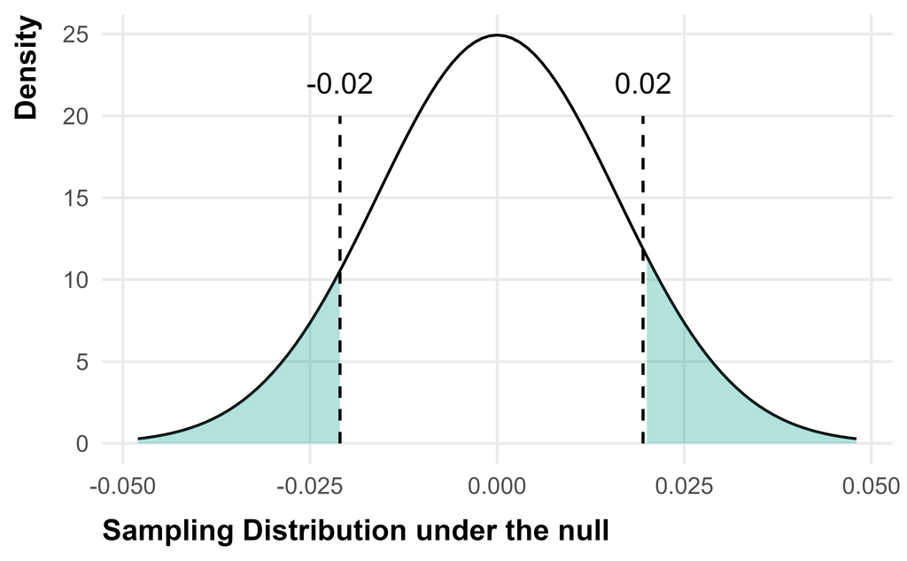

### P values for a difference

We can use R to calculate the area under one “tail” of this distribution:

```r
pnorm(0.02,
      mean=0,
      sd= 0.016,
      lower.tail=F)
```

```
[1] 0.1056498
```

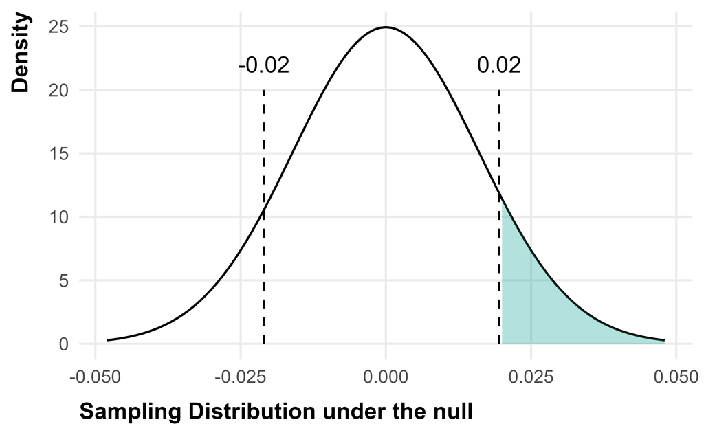

### P values for a difference

Since we’re looking for the area under *both* tails, we would double this:

```r
pnorm(0.02,
      mean=0,
      sd= 0.016,
      lower.tail=F) * 2
```

```
[1] 0.2112995
```

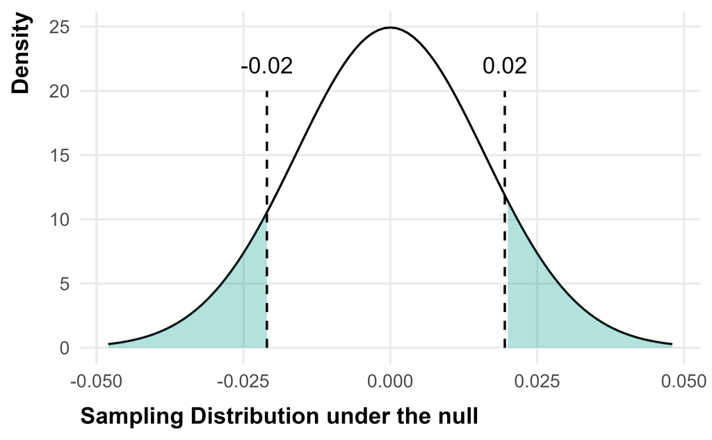

There is about a 21% chance of getting a difference equal to or absolutely greater than 0.02 if the effect is actually zero.

### P values for a difference

By *convention* p-values less than or equal to .05 are considered *statistically significant*

Both p-value and confidence intervals are based on the same math, and “significance” under a 95% confidence interval also means “significance” under a (two-tailed) p-value.

### Looking for Shy Trump Supporters

So what does this mean, and how do we know it?

### Looking for Shy Trump Supporters

- It means that we could rule out the possibility of “no effect” in four out of the 27 questions.
- We know if because of what we can infer about the sampling distribution of the differences.

### Notes

- P-values, confidence intervals, and statistical significance will come up again in this course.
- This same basic framework can be applied to a lot of different kinds of statistical tests, not just comparing means or proportions.
- Keep in mind that these only address random sampling error, not any of the other kinds of error we might encounter.

# Nuance!

## Statistical Insignificance

The results here don’t entirely rule out the possibility of a “Shy trump” supporter effect. There are really three reasons we might fail to find an effect:

- There’s actually no effect.
- Not enough observations/too much variability to detect an effect.
- Random chance.

## Statistical Insignificance

How large would the effect need to be for Pew’s method to catch it?

$$\frac{\text{Web vs. Phone}}{SE_\text{Web-Phone}}$$

## Statistical Insignificance

How large would the difference in our sample need to be for Pew’s study to find a significant result?

$$\frac{\text{Effect}}{0.016} = 1.96$$

At this sample size/standard error, the effect would need to be a little over $\pm3\%$ to be significant.

$$1.96 \times 0.016 = 0.03136$$

## Statistical Insignificance

- On the other hand, Pew asked multiple questions about views on Trump, and none of them showed significant mode differences.
- Other analyses of this phenomenon were also unable to find significant effects. (Dropp 2016; Coppock 2017)

[figure not shown]

## Complex Surveys and Design Effects

- Pew recruited respondents using a complex sampling method, and responses were weighted to be more representative of the U.S. population.
- These methods should make us more uncertain about the results.

## Design Effects

Design effects are one way to quantify the additional uncertainty introduced by a complex sampling method. The design effect is the ratio of the variance under a complex design compared to the variance you would get from a simple random sample.

## Design Effects

Pew reports their design effect is 2.99, so our variance should be approximately 3 times larger than what we initially calculated.

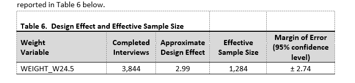

## Design Effects

Multiplying the variance by the design effect means that there’s even more random sampling error expected here.

$$SE_{\bar{y}_{\text{web}} - \bar{y}_{\text{phone}}} = \sqrt{\frac{0.244}{1,778} + \frac{0.246}{2,066}} \times \sqrt{2.99} = 0.028$$

$$\text{This difference is }\frac{0.02}{0.028} = .71 \text{ standard errors away from 0}$$

This works out to around a p value of around .47, well above the conventional threshold for significance.

## Design Effects

We can also formulate this as a 95% confidence interval around the difference of means.

$$0.02 \pm 0.028\times 1.96 = (-0.035,0.075)$$

## References

Coppock, Alexander. 2017. “Did Shy Trump Supporters Bias the 2016 Polls? Evidence from a Nationally-Representative List Experiment.” *Statistics, Politics and Policy* 8 (1): 29–40.

Courtney Kennedy, Andrew Mercer, Scott Keeter, and Arnold Lau. 2017. *Are Telephone Polls Understating Support for Trump? — Pewresearch.org*. [Https://www.pewresearch.org/methods/2017/03/31/are-telephone-polls-understating-support-for-trump-2/](https://www.pewresearch.org/methods/2017/03/31/are-telephone-polls-understating-support-for-trump-2/).

Dropp, Kyle. 2016. *How We Conducted Our “Shy Trumper” Study.* https://morningconsult.com/2016/11/03/shy-trump-social-desirability-undercover-voter-study/.